# TNC_Analogs1

# What do raw and sqrt transformed data look like:

## Raw AET and deficit histograms:

- Data plotted are a random 10,000 pixel subsample of the 35X10^6 Oregon pixels (full dataset takes too long to plot)
- These are “overlapping” histograms: histogram of non-forest plotted over histogram of forest pixels
- Histogram bars are transparent to facilitate interpretation.

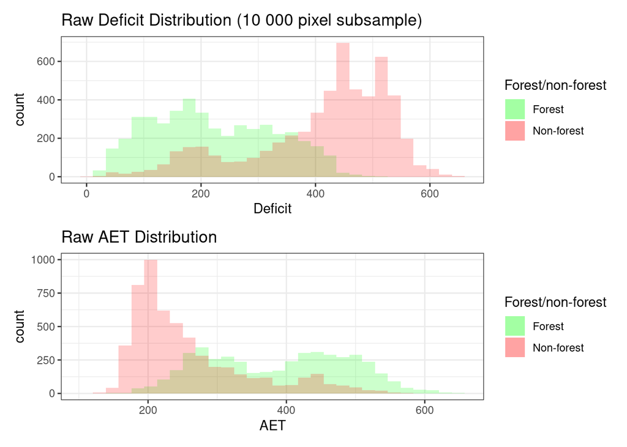

## SQRT-transformed AET and deficit histograms:

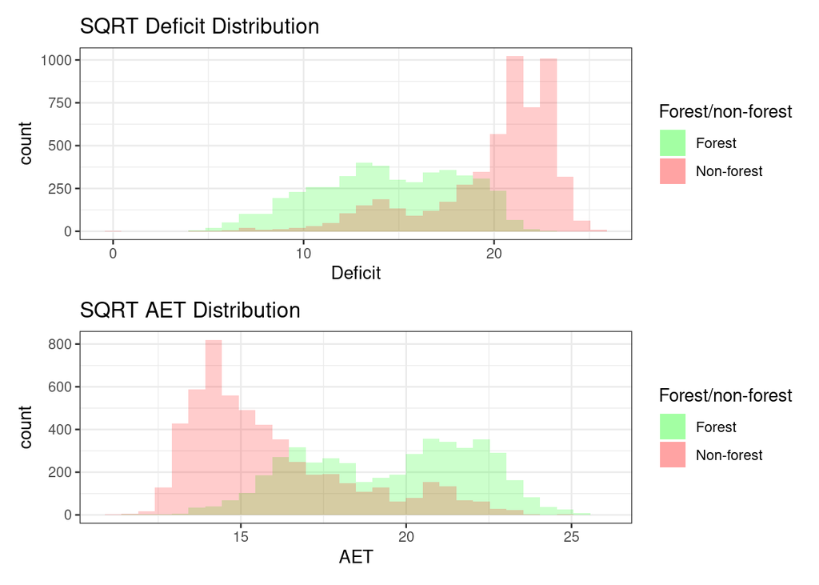

# What is the distribution of forests and non-forests in the AET/deficit climate space?

## 1= forest, 0 = non-forest.

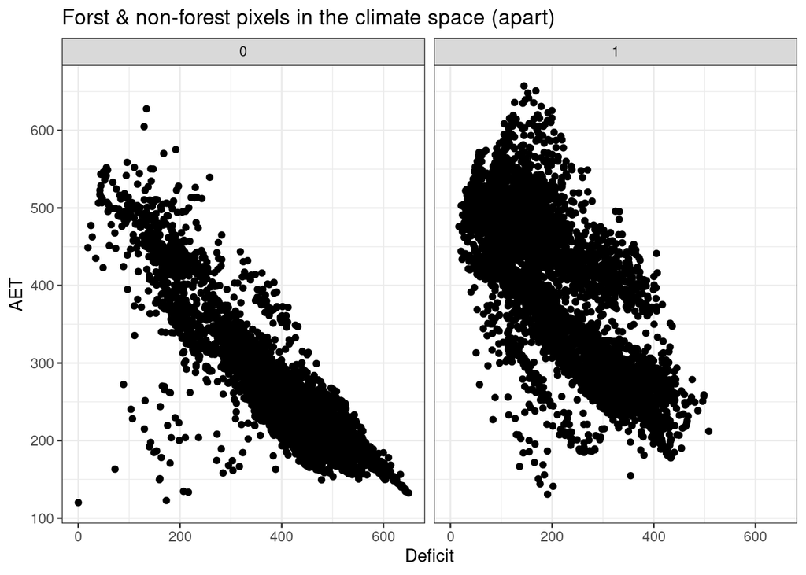

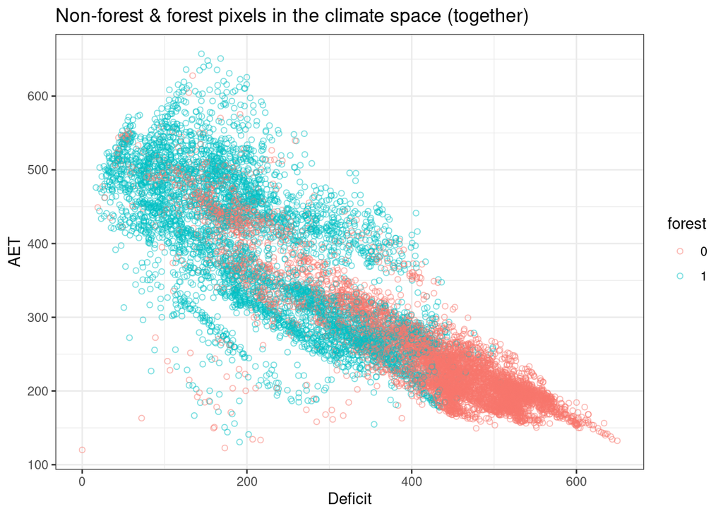

- ~ 400 mm deficit value seems like the the forest cutoff (in agreement with Stephenson 1990)
- Forest and non-forest pixels share much of the climate space defined by AET and Deficit

# Where do the misclassified pixels lie in the climate space:

- Using ~ 1 unit climate bin size with square-root transformed data
- 7 analogs used for classification

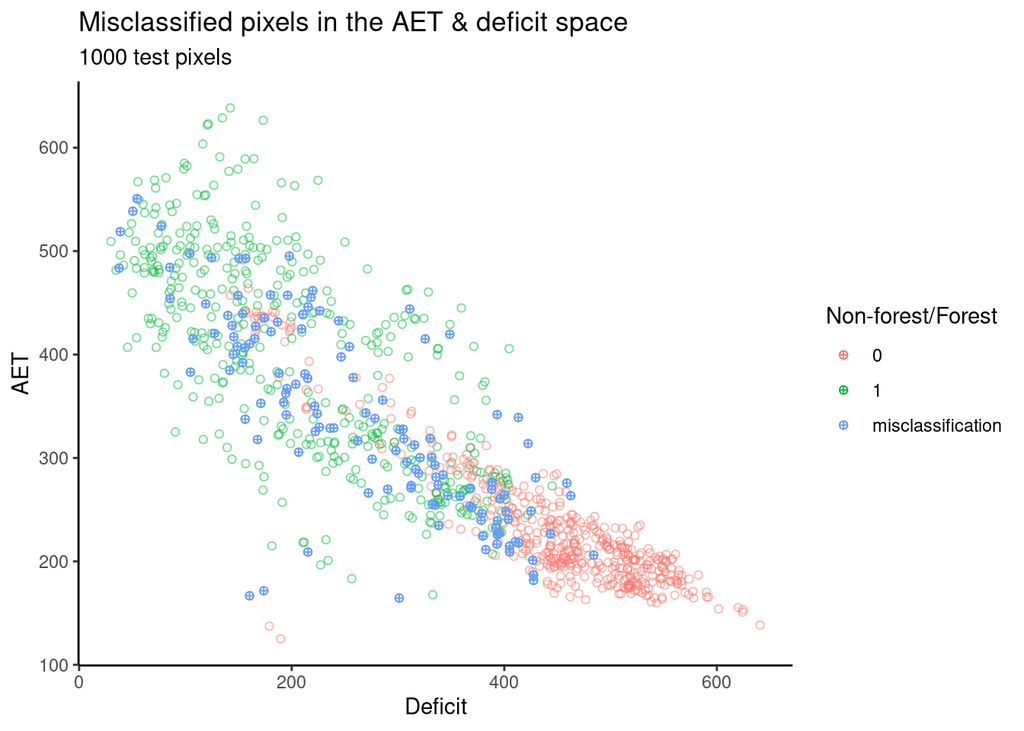

## Histogram of misclassificaitons by Defiict:

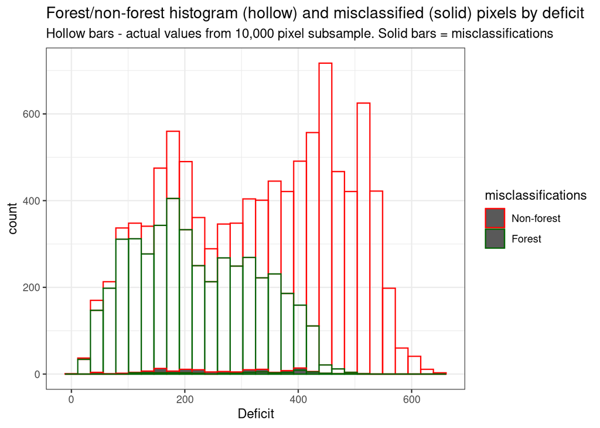

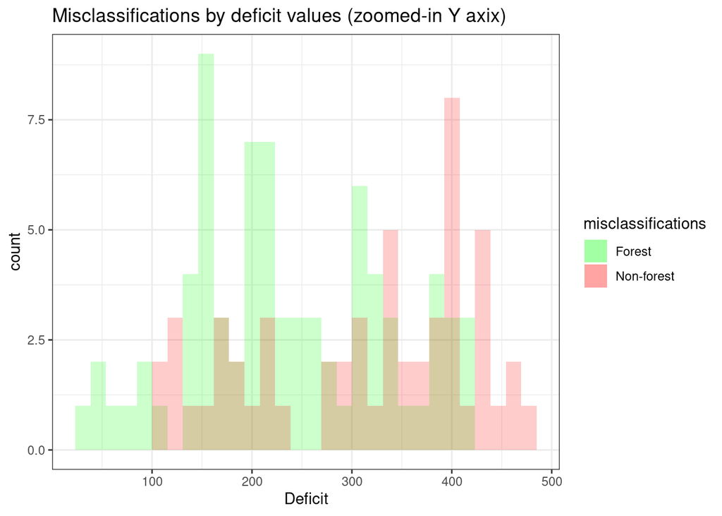

- Misclassifications are not limited to the vicinity of the 400 mm of deficit
- They happen at all the overlapping values of deficit

## Misclassifications by AET values:

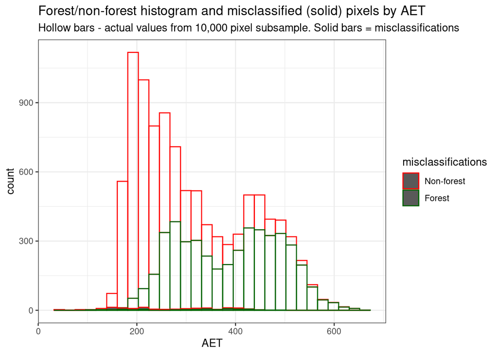

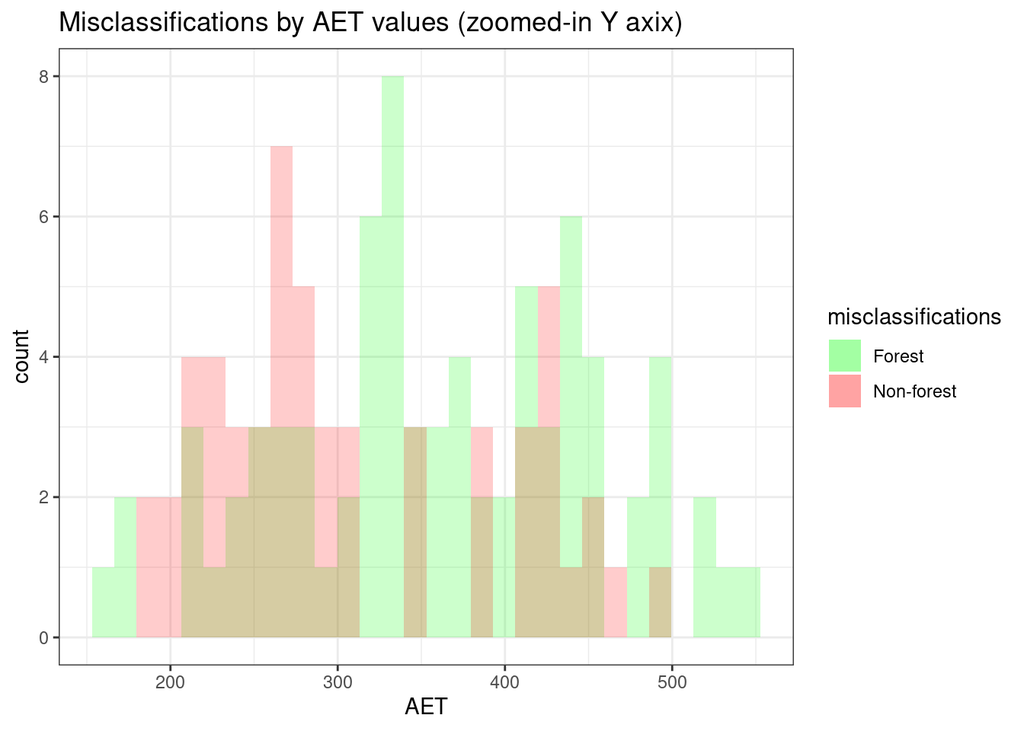

# What is the effect of AET and deficit window size on forest/non-forest classificaiton accuracy (raw data):

- Re-ran tests for raw and square-root transformed data
- AET and deficit bin sizes are identical
- Considered 7 analogs
- 50 km buffer

## Re-runs of the accuracy tests. Raw data:

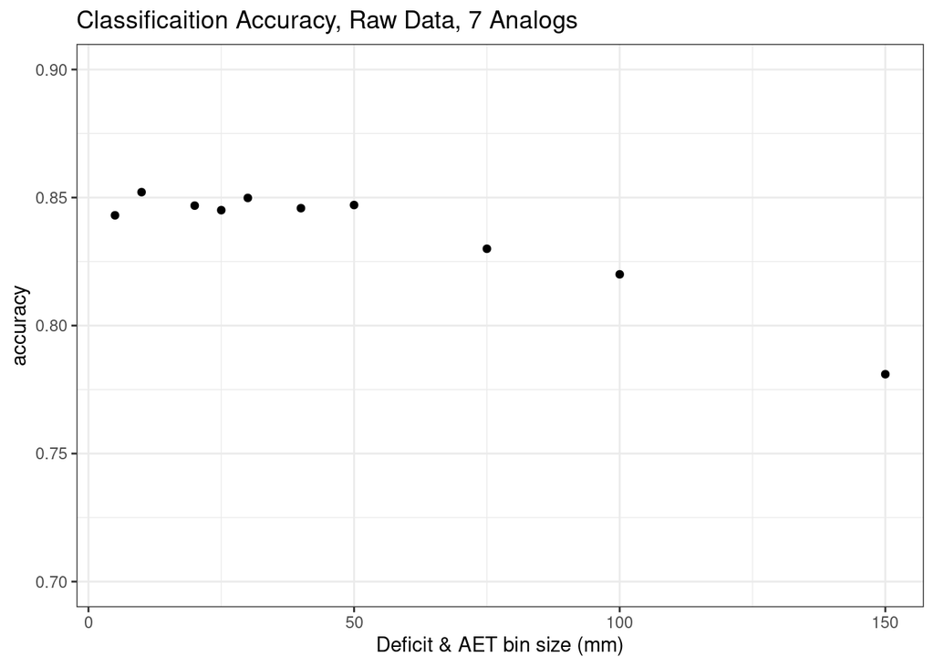

## Re-runs of the accuracy tests, squre-root transformed data:

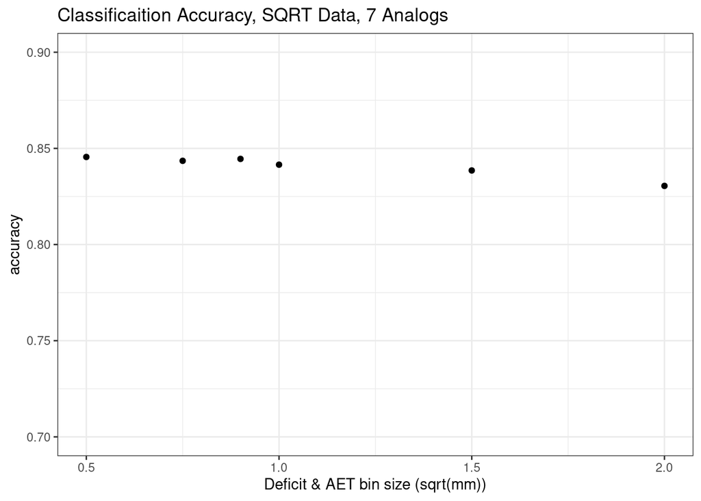

# What is the effect of considering different number of analogs for projection classification?

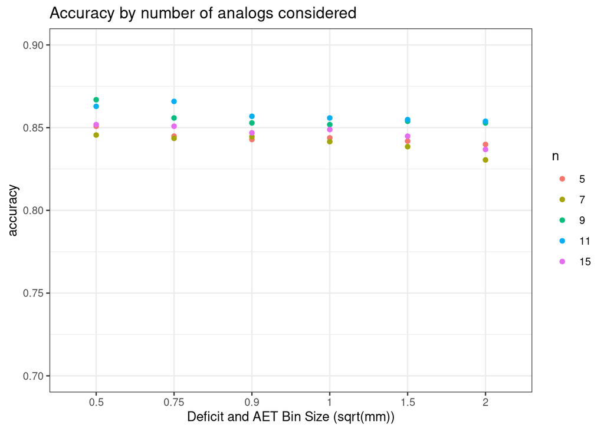

# Where are the 1000 focal plots located?

```r
library(tidyverse)
library(raster)
```

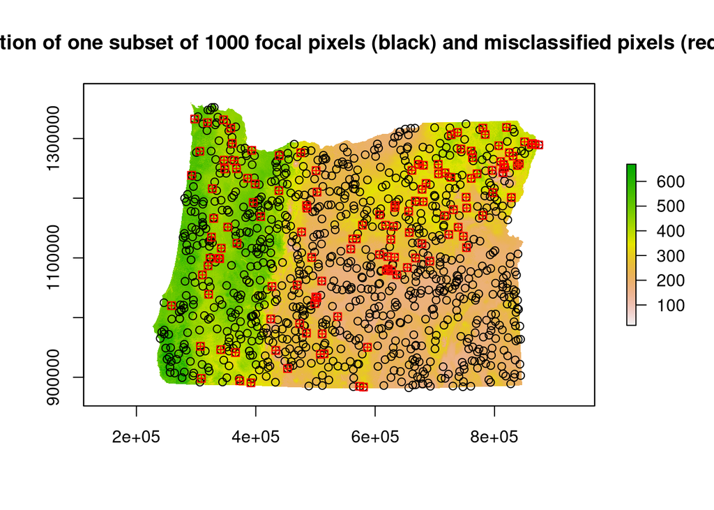

```r
aet<-raster("../data/aet_trouble/AET/AET.img")
data11<-readRDS("../outputs/accuracy2_2_11NN50km.rds")

# map misclassifications:
mis<-readRDS("../outputs/accuracy_sqrt_circa_1mm_bins_7nn.rds")

# pick out misclassificaitons for one column only:
mis1<-mis%>%
  filter(forest.pred0.75_1!=forest)


plot(aet, main = "Location of one subset of 1000 focal pixels (black) and misclassified pixels (red)")
points(mis[, c(1:2)])
points(mis1[, c(1:2)], col='red', pch=12)
```

# Summary:

## Effect of climate bin size:

- Raw and sqare-root transformed data appear to have equal accuracy.
  - Previous results, where raw data had lower accuracy were likely a result of a different search criteria - I looked at a number of them early on and did not label my results carefully.
- Bin sizes (raw and square-root transformed) do not have a strong effect on accuracy.
- Thoughts on the lack of bin size sensitivity:
  - Perhaps picking the “closest” analogs overrides the effect of widening the climate bin
  - Low sensitivity to bin sizes is in line with the broad overlap of forested and non-forested plots in the AET and Deficit space. Narrower bin is not necessarily meaningful.
- The effect of # of analogs considered on accuracy is also weak, and is likely a spurious result of the focal subset considered (my algorithm picks a new set of 1000 focal plots for each test)
- Distance still has a strong effect on accuracy.
- Perhaps the result of the “dynamic” climate bin size: smaller bins for lower values of AET and Deficit, larger bins for high values of AET and Deficit.